# Snowshoe Hares - Exploratory Report

Julia Wilson

11/4/2021

### Introduction

This report provides an exploratory overview of snowshoe hare populations from 1998 - 2012 at the Bonanza Creek Experimental Forest in Alaska (Kielland, K.et al. (2017)). Specifically, the report evaluates snowshoe hare trap counts over 13 years. It also compares juvenile hare weights across males and females at three sites; Bonbs, Bonanza Mature, and Bonanza Riparian. Finally, the report analyzes a potentialrelationship between hind foot length (mm) and weights (g).

### Data & Analysis

Snowshoe hare trap count, weight and hind foot length data were collected and made available by Senior Investigator Knut Kielland and colleagues at the Bonanza Creek (LTER) site in Alaska. Capture - recapture studies were conducted of snowshoe hares at 5 locales in the Tanana Valley. The data contain observations for 378 juvenile hares, collected over 13 years (1998 - 2012). Following exploratory data visualization, juvenile hare male and female weights are compared by two-sample t-tests using a significance level (α) f 0.05 throughout. Differences between the groups are described by Cohen’s *d* effect size. The relationship between weight and hind foot length is explored by a simple linear regression. All analyses are in R version 4.1.1 using R studio version 1.4.1717.

### Preliminary Results

#### A. Juvenile Hare Trap Counts

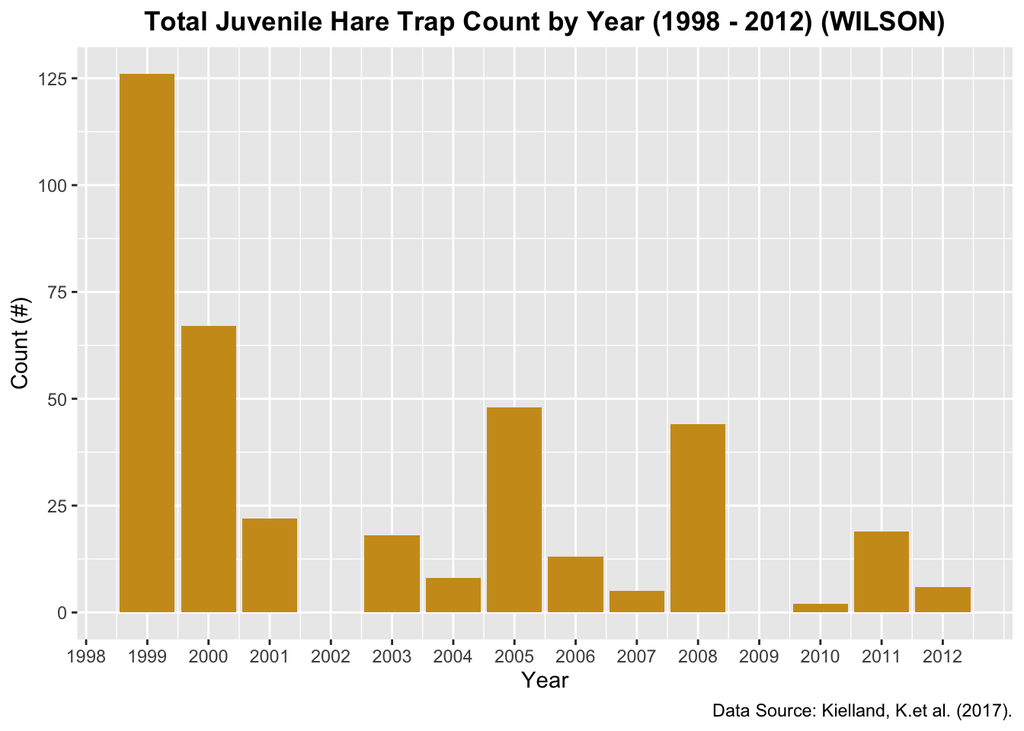

**Figure 1: Total Juvenile Hare Trap Count by Year** Total juvenile hare trap counts per year from 1998 - 2012.

##### Juvenile Trap Count Analysis

To standardize the juvenile hare population in future analyses, the number of days and traps in the study need to be consistent every year.

#### B. Juvenile Hare Weights

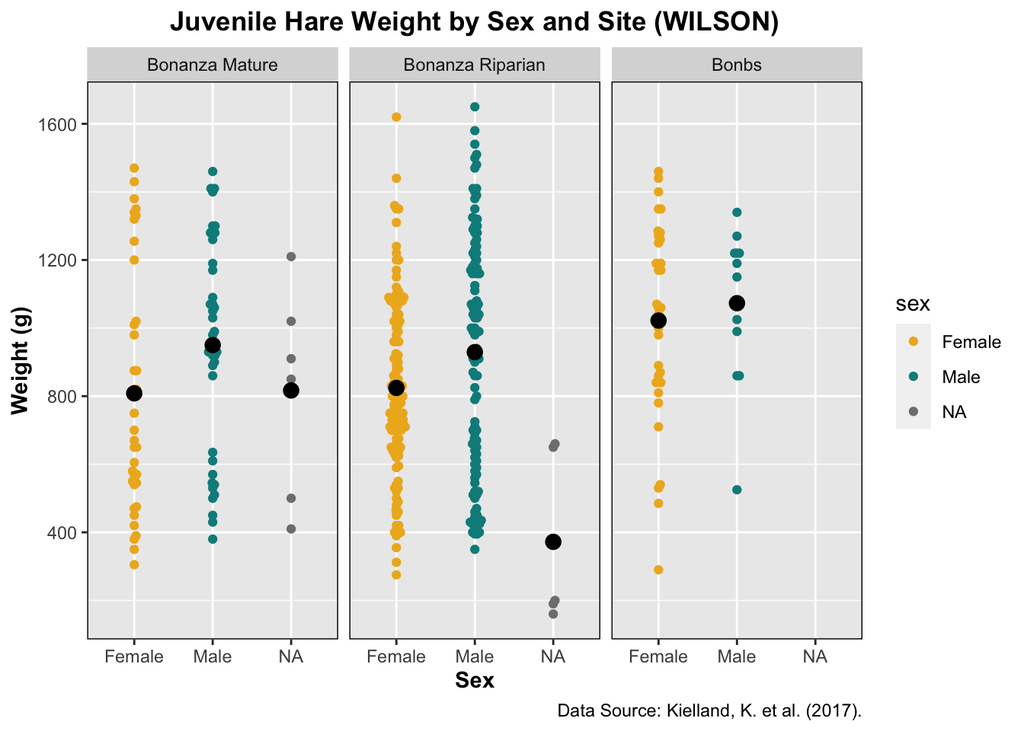

**Table 1.** Descriptive statistics (mean, median, max, min, standard deviation, and sample size) for females and males at three sites; Bonbs, Bonanza Riparian, and Bonanza Mature. Data: Kielland, K. et al. (2017).

| Site | Sex | Mean (g) | Median (g) | Max (g) | Min (g) | Standard Deviation (g) | Sample Size |
| --- | --- | --- | --- | --- | --- | --- | --- |
| Bonanza Mature | Female | 808.2 | 685 | 1470 | 305 | 361.1 | 36 |
| Bonanza Mature | Male | 950.1 | 965 | 1460 | 380 | 314.7 | 40 |
| Bonanza Mature | NA | 816.7 | 880 | 1210 | 410 | 307.1 | 6 |
| Bonanza Riparian | Female | 824.1 | 800 | 1620 | 275 | 255.0 | 127 |
| Bonanza Riparian | Male | 929.3 | 990 | 1650 | 350 | 349.2 | 110 |
| Bonanza Riparian | NA | 372.0 | 200 | 660 | 160 | 258.8 | 5 |
| Bonbs | Female | 1022.1 | 1060 | 1460 | 290 | 293.0 | 34 |
| Bonbs | Male | 1073.1 | 1150 | 1340 | 525 | 222.6 | 13 |

##### Juvenile Weight Analysis

The graph shows a visual difference in counts for juvenile hare weights for both males and females. Bonanza Riparian has the highest sample size of juvenile hares at 242. This is followed by Bonanza Mature with a sample size of 82 and Bonbs at 47. The central tendency for females is generally lower than the central tendency of males. This is visualized by the black dots on the graph which represent mean values. The sample size impacts the visible trends and the accuracy of the data.

#### C. Juvenile Weight Comparison

**Table 2.** Descriptive statistics (mean, median, max, min, standard deviation, and sample size) for female and male weight (g). Data: Kielland, K. et al. (2017).

| Sex | Mean (g) | Median (g) | Max (g) | Min (g) | Standard Deviation (g) | Sample Size |
| --- | --- | --- | --- | --- | --- | --- |
| Female | 855.4 | 825 | 1620 | 275 | 292.3 | 200 |
| Male | 945.9 | 990 | 1650 | 350 | 333.2 | 163 |
| NA | 614.5 | 650 | 1210 | 160 | 357.6 | 15 |

#### D. Juvenile Weight & Hind Foot Length

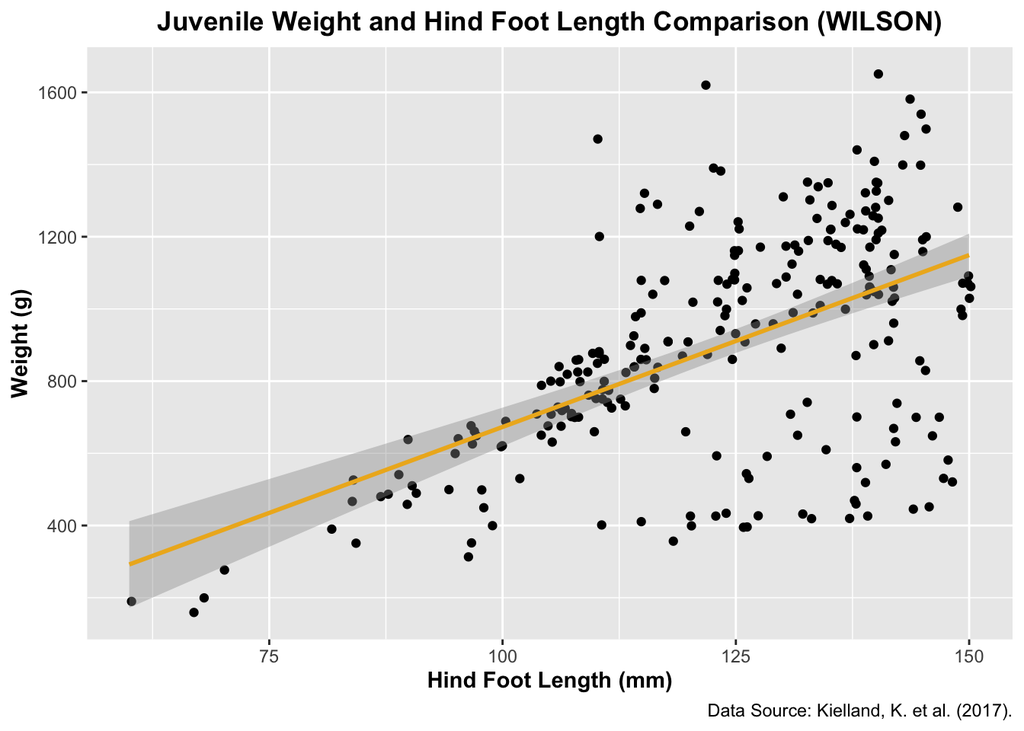

**Figure 3: Juvenile Weight and Hind Foot Length Comparison** Relationship between Hind Foot Length (mm) and Weight (g) for juvenile snowshoe hares recorded from 1998 2012 at Bonanza Creek. Points indicate individual juvenile hare measurements.

##### Juvenile Weight and Hindfoot Analysis

The **slope** is 9.52 (g/mm). On average we expect weight to increase by 9.52 for every 1 mm increase in hind foot length. The **y-intercept** is -279.3 (g). For a juvenile hare with a 0 mm hind foot length, we expect an average hare mass of -279.3 (g).

The **R^2 value** of 0.3 means that 30% of the variance in hare weight is explained by hind foot length. The **Pearson’s *r* Correlation** is 0.5. This value represents a moderate correlation between the change in weight and hind foot length.

Despite the regression line illustrating a positive correlation, the R^2 and Pearson’s *r* values only support a moderate correlation between weight and hind foot length.

### Summary

Next Steps:

- Multiple linear regression to understand the relationship between sex, hind foot length and weight

### Citations

David Robinson, Alex Hayes and Simon Couch (2021). broom: Convert Statistical Objects into Tidy Tibbles. R package version 0.7.9. https://CRAN.R-project.org/package=broom

Erik Clarke and Scott Sherrill-Mix (2017). ggbeeswarm: Categorical Scatter (Violin Point) Plots. R package version 0.6.0. [<https://CRAN.R-project.org/package=ggbeeswarm>](https://CRAN.R-project.org/package=ggbeeswarm).

Garrett Grolemund, Hadley Wickham (2011). Dates and Times Made Easy with lubridate. Journal of Statistical Software, 40(3), 1-25. URL [<https://www.jstatsoft.org/v40/i03/>](https://www.jstatsoft.org/v40/i03/).

Hao Zhu (2021). kableExtra: Construct Complex Table with ‘kable’ and Pipe Syntax. R package version 1.3.4. [<https://CRAN.R-project.org/package=kableExtra>](https://CRAN.R-project.org/package=kableExtra).

Kielland, K., F.S. Chapin, R.W. Ruess, and Bonanza Creek LTER. 2017. Snowshoe hare physical data in Bonanza Creek Experimental Forest: 1999-Present ver 22. Environmental Data Initiative. https://doi.org/10.6073/pasta/03dce4856d79b91557d8e6ce2cbcdc14

Kirill Müller (2020). here: A Simpler Way to Find Your Files. R package version 1.0.1. https://CRAN.R-project.org/package=here

Sam Firke (2021). janitor: Simple Tools for Examining and Cleaning Dirty Data. R package version 2.1.0. https://CRAN.R-project.org/package=janitor.

Torchiano M (2020). *effsize: Efficient Effect Size Computation*. doi: 10.5281/zenodo.1480624 (URL: https://doi.org/10.5281/zenodo.1480624), R package version 0.8.1, <URL: https://CRAN.R-project.org/package=effsize>.

Wickham et al., (2019). Welcome to the tidyverse. Journal of Open Source Software, 4(43), 1686, [<https://doi.org/10.21105/joss.01686>](https://doi.org/10.21105/joss.01686).